# 3.1. Numeric variable analysis

Ucitavanje potrebnih biblioteka:

```r
install.packages('reshape2')
```

```
Error in install.packages : Updating loaded packages
```

```r
install.packages('patchwork')
```

```
Error in install.packages : Updating loaded packages
```

```r
library(tidyverse)
library(lubridate)
library(reshape2)
library(patchwork)
```

## 1. Age

Osnovni opis varijable Age u train skupu:

```r
summary(train$Age)
```

```
   Min. 1st Qu.  Median    Mean 3rd Qu.    Max.    NA's
  18.00   30.00   41.00   41.15   53.00   64.00   18705
```

Osnovni opis varijable Age u test skupu:

```r
summary(test$Age)
```

```
   Min. 1st Qu.  Median    Mean 3rd Qu.    Max.    NA's
  18.00   30.00   41.00   41.14   53.00   64.00   12489
```

### Graficka reprezentacija podataka

Prikaz varijable Age pomocu histograma:

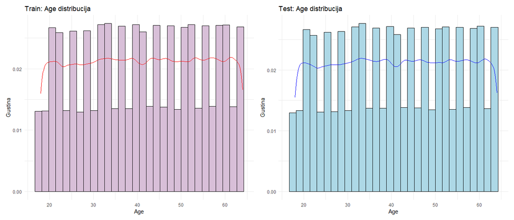

```r
plot.train <- ggplot(train, aes(x = Age)) +
  geom_histogram(aes(y = ..density..), bins = 30, fill = "thistle", color = "black") +
  geom_density(color = "red") +
  theme_minimal() +
  labs(title = "Train: Age distribucija", x = "Age", y = "Gustina")

plot.test <- ggplot(test, aes(x = Age)) +
  geom_histogram(aes(y = ..density..), bins = 30, fill = "lightblue", color = "black") +
  geom_density(color = "blue") +
  theme_minimal() +
  labs(title = "Test: Age distribucija", x = "Age", y = "Gustina")

plot.train | plot.test
```

Prikaz varijable Age pomocu boxplot-a:

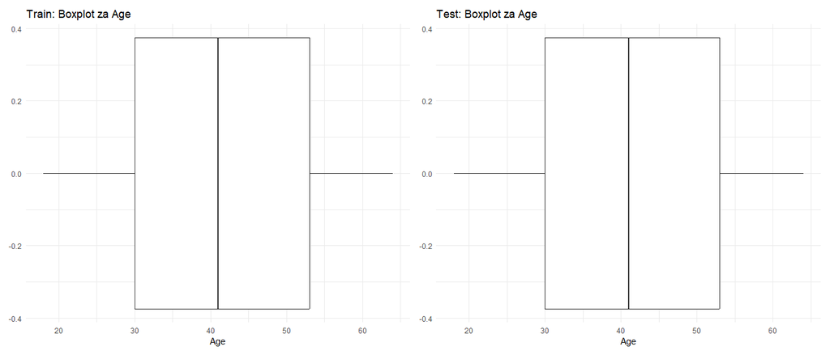

```r
plot.train <- ggplot(train, aes(x = Age)) +
  geom_boxplot() +
  theme_minimal() +
  labs(title = "Train: Boxplot za Age", x = "Age")

plot.test <- ggplot(test, aes(x = Age)) +
  geom_boxplot() +
  theme_minimal() +
  labs(title = "Test: Boxplot za Age", x = "Age")

plot.train | plot.test
```

Prikaz varijable Age pomocu Q-Q plota:

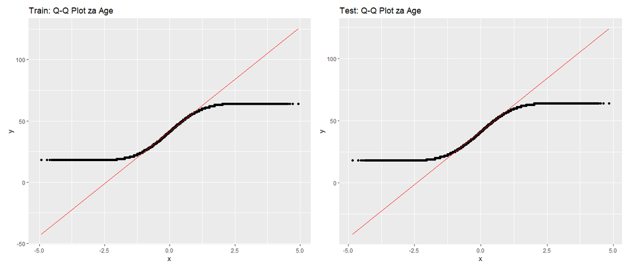

```r
plot.train <- ggplot(train, aes(sample = Age)) +
  stat_qq() +
  stat_qq_line(color = "red") +
  labs(title = "Train: Q-Q Plot za Age")

plot.test <- ggplot(test, aes(sample = Age)) +
  stat_qq() +
  stat_qq_line(color = "red") +
  labs(title = "Test: Q-Q Plot za Age")

plot.train | plot.test
```

Statisticko testiranje normalnosti varijable Age za train skup:

```r
set.seed(123)
p.values.train <- replicate(500, shapiro.test(sample(train$Age, 3000))$p.value)
p.mean.train <- mean(p.values.train)

if (p.mean.train > 0.05) {
  print("Train: Varijabla Age ima normalnu raspodelu.")
} else {
  print("Train: Varijabla Age nema normalnu raspodelu.")
}
```

```
[1] "Train: Varijabla Age nema normalnu raspodelu."
```

Statisticko testiranje normalnosti varijable Age za test skup:

```r
p.values.test <- replicate(500, shapiro.test(sample(test$Age, 3000))$p.value)
p.mean.test <- mean(p.values.test)

if (p.mean.test > 0.05) {
  print("Test: Varijabla Age ima normalnu raspodelu.")
} else {
  print("Test: Varijabla Age nema normalnu raspodelu.")
}
```

```
[1] "Test: Varijabla Age nema normalnu raspodelu."
```

## 2. Annual.Income

Osnovni opis varijable Annual.Income za train skup:

```r
summary(train$Annual.Income)
```

```
   Min. 1st Qu.  Median    Mean 3rd Qu.    Max.    NA's
      1    8001   23911   32745   44634  149997   44949
```

Osnovni opis varijable Annual.Income za test skup:

```r
summary(test$Annual.Income)
```

```
   Min. 1st Qu.  Median    Mean 3rd Qu.    Max.    NA's
      2    8048   23981   32804   44660  149997   29860
```

### Graficka reprezentacija podataka

Prikaz varijable Annual.Income pomocu histograma:

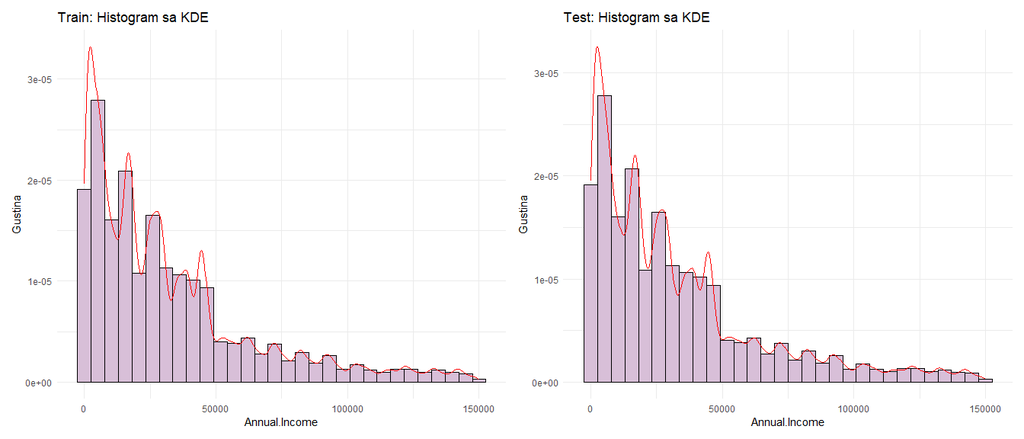

```r
plot.train <- ggplot(train, aes(x = Annual.Income)) +
  geom_histogram(aes(y = ..density..), bins = 30, fill = "thistle", color = "black") +
  geom_density(color = "red") +
  theme_minimal() +
  labs(title = "Train: Histogram sa KDE", x = "Annual.Income", y = "Gustina")

plot.test <- ggplot(test, aes(x = Annual.Income)) +
  geom_histogram(aes(y = ..density..), bins = 30, fill = "thistle", color = "black") +
  geom_density(color = "red") +
  theme_minimal() +
  labs(title = "Test: Histogram sa KDE", x = "Annual.Income", y = "Gustina")

plot.train | plot.test
```

Prikaz varijable Annual.Income pomocu boxplot-a:

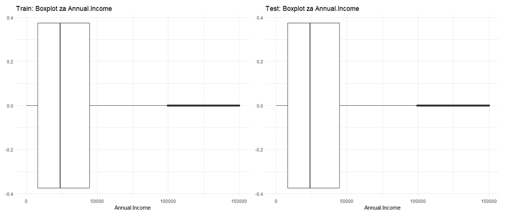

```r
plot.train <- ggplot(train, aes(x = Annual.Income))  +
  geom_boxplot() +
  theme_minimal() +
  labs(title = "Train: Boxplot za Annual.Income", x = "Annual.Income")

plot.test <- ggplot(test, aes(x = Annual.Income))  +
  geom_boxplot() +
  theme_minimal() +
  labs(title = "Test: Boxplot za Annual.Income", x = "Annual.Income")

plot.train | plot.test
```

Prikaz varijable Annual.Income pomocu Q-Q plota:

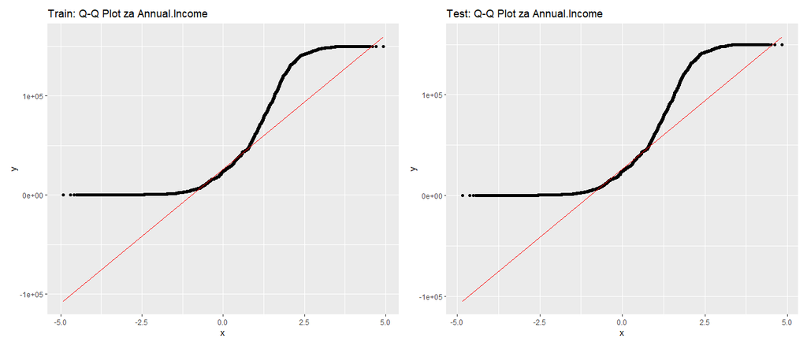

```r
plot.train <- ggplot(train, aes(sample = Annual.Income)) +
  stat_qq() +
  stat_qq_line(color = "red") +
  labs(title = "Train: Q-Q Plot za Annual.Income")

plot.test <- ggplot(test, aes(sample = Annual.Income)) +
  stat_qq() +
  stat_qq_line(color = "red") +
  labs(title = "Test: Q-Q Plot za Annual.Income")

plot.train | plot.test
```

Statisticko testiranje normalnosti varijable Annual.Income za train skup:

```r
set.seed(123)
p.values.train <- replicate(500, shapiro.test(sample(train$Annual.Income, 3000))$p.value)
p.mean.train <- mean(p.values.train)

if (p.mean.train > 0.05) {
  print("Train: Varijabla Annual.Income ima normalnu raspodelu.")
} else {
  print("Train: Varijabla Annual.Income nema normalnu raspodelu.")
}
```

```
[1] "Train: Varijabla Annual.Income nema normalnu raspodelu."
```

Statisticko testiranje normalnosti varijable Annual.Income za test skup:

```r
set.seed(123)
p.values.test <- replicate(500, shapiro.test(sample(test$Annual.Income, 3000))$p.value)
p.mean.test <- mean(p.values.test)

if (p.mean.test > 0.05) {
  print("Test: Varijabla Annual.Income ima normalnu raspodelu.")
} else {
  print("Test: Varijabla Annual.Income nema normalnu raspodelu.")
}
```

```
[1] "Test: Varijabla Annual.Income nema normalnu raspodelu."
```

## 3. Number.of.Dependents

Osnovni opis varijable Number.of.Dependents za train skup:

```r
summary(train$Number.of.Dependents)
```

```
   Min. 1st Qu.  Median    Mean 3rd Qu.    Max.    NA's
   0.00    1.00    2.00    2.01    3.00    4.00  109672
```

Osnovni opis varijable Number.of.Dependents za test skup:

```r
summary(test$Number.of.Dependents)
```

```
   Min. 1st Qu.  Median    Mean 3rd Qu.    Max.    NA's
  0.000   1.000   2.000   2.009   3.000   4.000   73130
```

### Graficka reprezentacija podataka

Prikaz varijable Number.of.Dependents pomocu histograma:

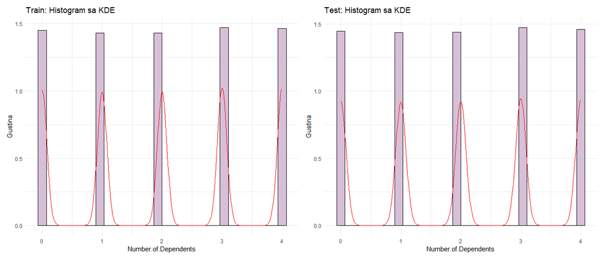

```r
plot.train <- ggplot(train, aes(x = Number.of.Dependents)) +
  geom_histogram(aes(y = ..density..), bins = 30, fill = "thistle", color = "black") +
  geom_density(color = "red") +
  theme_minimal() +
  labs(title = "Train: Histogram sa KDE", x = "Number.of.Dependents", y = "Gustina")

plot.test <- ggplot(test, aes(x = Number.of.Dependents)) +
  geom_histogram(aes(y = ..density..), bins = 30, fill = "thistle", color = "black") +
  geom_density(color = "red") +
  theme_minimal() +
  labs(title = "Test: Histogram sa KDE", x = "Number.of.Dependents", y = "Gustina")

plot.train | plot.test
```

Prikaz varijable Number.of.Dependents pomocu boxplot-a:

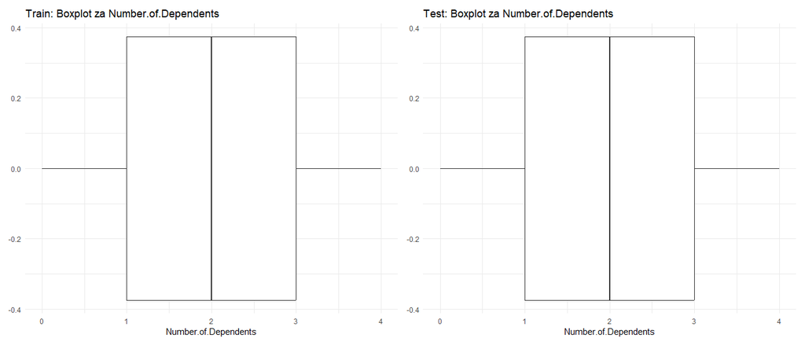

```r
plot.train <- ggplot(train, aes(x = Number.of.Dependents))  +
  geom_boxplot() +
  theme_minimal() +
  labs(title = "Train: Boxplot za Number.of.Dependents", x = "Number.of.Dependents")

plot.test <- ggplot(test, aes(x = Number.of.Dependents))  +
  geom_boxplot() +
  theme_minimal() +
  labs(title = "Test: Boxplot za Number.of.Dependents", x = "Number.of.Dependents")

plot.train | plot.test
```

Prikaz varijable Number.of.Dependents pomocu Q-Q plota:

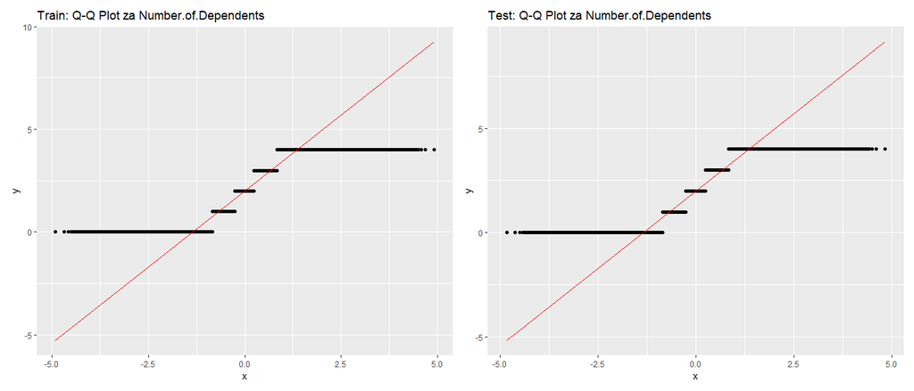

```r
plot.train <- ggplot(train, aes(sample = Number.of.Dependents)) +
  stat_qq() +
  stat_qq_line(color = "red") +
  labs(title = "Train: Q-Q Plot za Number.of.Dependents")

plot.test <- ggplot(test, aes(sample = Number.of.Dependents)) +
  stat_qq() +
  stat_qq_line(color = "red") +
  labs(title = "Test: Q-Q Plot za Number.of.Dependents")

plot.train | plot.test
```

Statisticko testiranje normalnosti varijable Number.of.Dependents za train skup:

```r
set.seed(123)
p.values.train <- replicate(500, shapiro.test(sample(train$Number.of.Dependents, 3000))$p.value)
p.mean.train <- mean(p.values.train)

if (p.mean.train > 0.05) {
  print("Train: Varijabla Number.of.Dependents ima normalnu raspodelu.")
} else {
  print("Train: Varijabla Number.of.Dependents nema normalnu raspodelu.")
}
```

```
[1] "Train: Varijabla Number.of.Dependents nema normalnu raspodelu."
```

Statisticko testiranje normalnosti varijable Number.of.Dependents za test skup:

```r
p.values.test <- replicate(500, shapiro.test(sample(test$Number.of.Dependents, 3000))$p.value)
p.mean.test <- mean(p.values.test)

if (p.mean.test > 0.05) {
  print("Test: Varijabla Number.of.Dependents ima normalnu raspodelu.")
} else {
  print("Test: Varijabla Number.of.Dependents nema normalnu raspodelu.")
}
```

```
[1] "Test: Varijabla Number.of.Dependents nema normalnu raspodelu."
```

## 4. Health.Score

Osnovni opis varijable Health.Score za train skup:

```r
summary(train$Health.Score)
```

```
   Min. 1st Qu.  Median    Mean 3rd Qu.    Max.    NA's
  2.012  15.919  24.579  25.614  34.527  58.976   74076
```

Osnovni opis varijable Health.Score za test skup:

```r
summary(test$Health.Score)
```

```
   Min. 1st Qu.  Median    Mean 3rd Qu.    Max.    NA's
  1.647  15.917  24.580  25.613  34.518  57.957   49449
```

### Graficka reprezentacija podataka

Prikaz varijable Health.Score pomocu histograma:

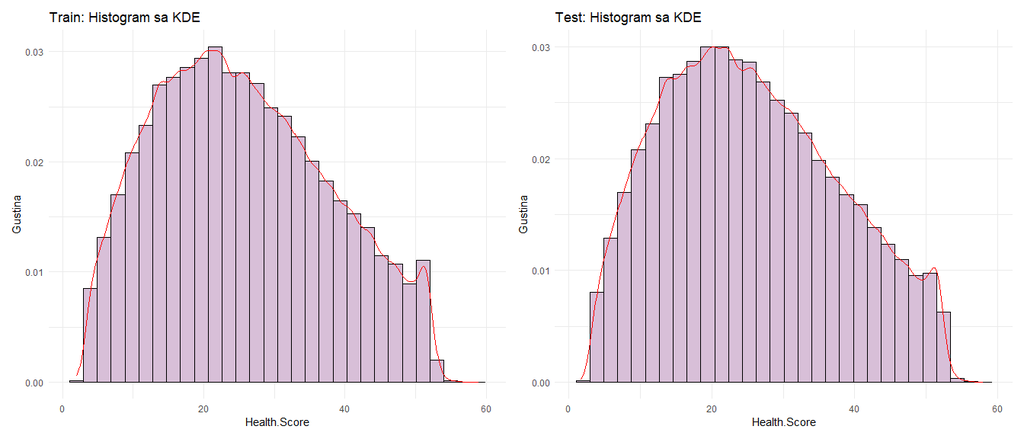

```r
plot.train <- ggplot(train, aes(x = Health.Score)) +
  geom_histogram(aes(y = ..density..), bins = 30, fill = "thistle", color = "black") +
  geom_density(color = "red") +
  theme_minimal() +
  labs(title = "Train: Histogram sa KDE", x = "Health.Score", y = "Gustina")

plot.test <- ggplot(test, aes(x = Health.Score)) +
  geom_histogram(aes(y = ..density..), bins = 30, fill = "thistle", color = "black") +
  geom_density(color = "red") +
  theme_minimal() +
  labs(title = "Test: Histogram sa KDE", x = "Health.Score", y = "Gustina")

plot.train | plot.test
```

Prikaz varijable Health.Score pomocu boxplot-a:

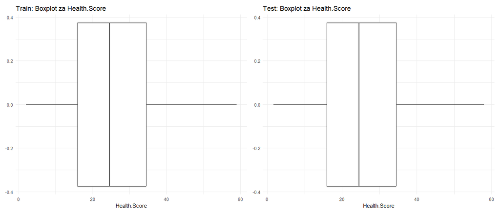

```r
plot.train <- ggplot(train, aes(x = Health.Score))  +
  geom_boxplot() +
  theme_minimal() +
  labs(title = "Train: Boxplot za Health.Score", x = "Health.Score")

plot.test <- ggplot(test, aes(x = Health.Score))  +
  geom_boxplot() +
  theme_minimal() +
  labs(title = "Test: Boxplot za Health.Score", x = "Health.Score")

plot.train | plot.test
```

Prikaz varijable Health.Score pomocu Q-Q plota:

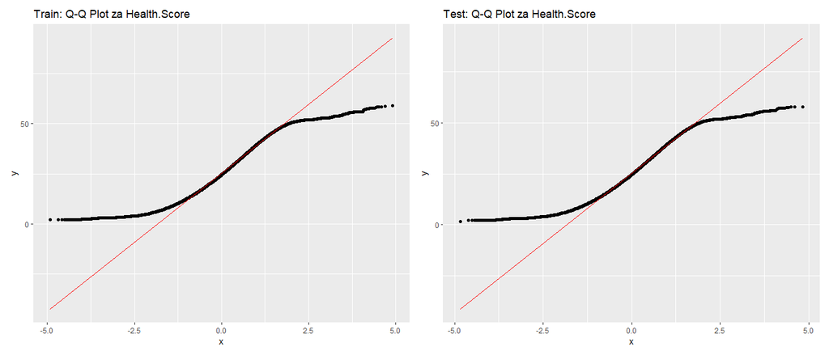

```r
plot.train <- ggplot(train, aes(sample = Health.Score)) +
  stat_qq() +
  stat_qq_line(color = "red") +
  labs(title = "Train: Q-Q Plot za Health.Score")

plot.test <- ggplot(test, aes(sample = Health.Score)) +
  stat_qq() +
  stat_qq_line(color = "red") +
  labs(title = "Test: Q-Q Plot za Health.Score")

plot.train | plot.test
```

Statisticko testiranje normalnosti varijable Health.Score za train skup:

```r
set.seed(123)
p.values.train <- replicate(500, shapiro.test(sample(train$Health.Score, 3000))$p.value)
p.mean.train <- mean(p.values.train)

if (p.mean.train > 0.05) {
  print("Train: Varijabla Health.Score ima normalnu raspodelu.")
} else {
  print("Train: Varijabla Health.Score nema normalnu raspodelu.")
}
```

```
[1] "Train: Varijabla Health.Score nema normalnu raspodelu."
```

Statisticko testiranje normalnosti varijable Health.Score za test skup:

```r
p.values.test <- replicate(500, shapiro.test(sample(test$Health.Score, 3000))$p.value)
p.mean.test <- mean(p.values.test)

if (p.mean.test > 0.05) {
  print("Test: Varijabla Health.Score ima normalnu raspodelu.")
} else {
  print("Test: Varijabla Health.Score nema normalnu raspodelu.")
}
```

```
[1] "Test: Varijabla Health.Score nema normalnu raspodelu."
```

## 5. Previous.Claims

Osnovni opis varijable Previous.Claims za train skup:

```r
summary(train$Previous.Claims)
```

```
   Min. 1st Qu.  Median    Mean 3rd Qu.    Max.    NA's
      0       0       1       1       2       9  364029
```

Osnovni opis varijable Previous.Claims za test skup:

```r
summary(test$Previous.Claims)
```

```
   Min. 1st Qu.  Median    Mean 3rd Qu.    Max.    NA's
  0.000   0.000   1.000   1.005   2.000   9.000  242802
```

### Graficka reprezentacija podataka

Prikaz varijable Previous.Claims pomocu histograma:

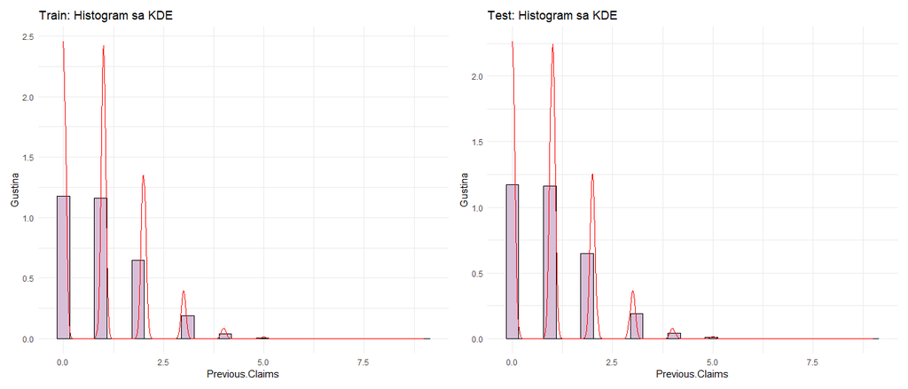

```r
plot.train <- ggplot(train, aes(x = Previous.Claims)) +
  geom_histogram(aes(y = ..density..), bins = 30, fill = "thistle", color = "black") +
  geom_density(color = "red") +
  theme_minimal() +
  labs(title = "Train: Histogram sa KDE", x = "Previous.Claims", y = "Gustina")

plot.test <- ggplot(test, aes(x = Previous.Claims)) +
  geom_histogram(aes(y = ..density..), bins = 30, fill = "thistle", color = "black") +
  geom_density(color = "red") +
  theme_minimal() +
  labs(title = "Test: Histogram sa KDE", x = "Previous.Claims", y = "Gustina")

plot.train | plot.test
```

Prikaz varijable Previous.Claims pomocu boxplot-a:

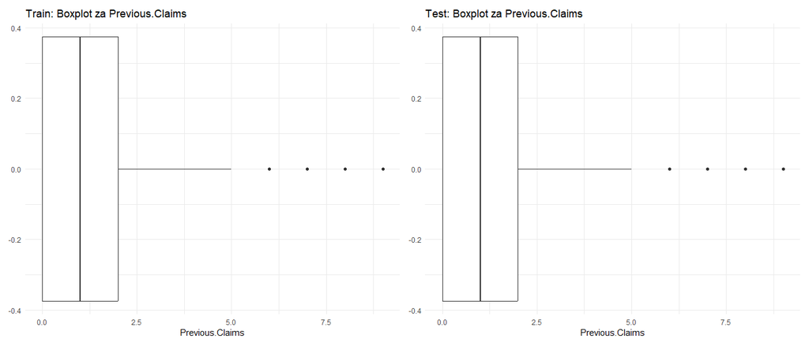

```r
plot.train <- ggplot(train, aes(x = Previous.Claims))  +
  geom_boxplot() +
  theme_minimal() +
  labs(title = "Train: Boxplot za Previous.Claims", x = "Previous.Claims")

plot.test <- ggplot(test, aes(x = Previous.Claims))  +
  geom_boxplot() +
  theme_minimal() +
  labs(title = "Test: Boxplot za Previous.Claims", x = "Previous.Claims")

plot.train | plot.test
```

Prikaz varijable Previous.Claims pomocu Q-Q plota:

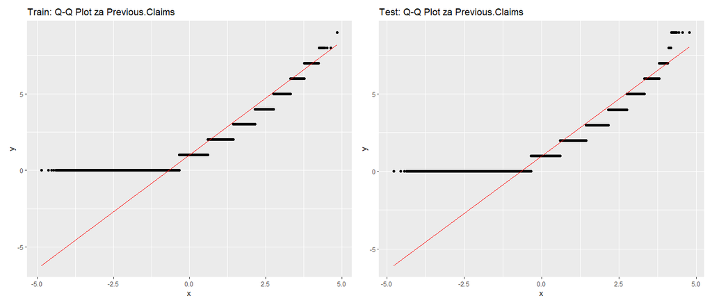

```r
plot.train <- ggplot(train, aes(sample = Previous.Claims)) +
  stat_qq() +
  stat_qq_line(color = "red") +
  labs(title = "Train: Q-Q Plot za Previous.Claims")

plot.test <- ggplot(test, aes(sample = Previous.Claims)) +
  stat_qq() +
  stat_qq_line(color = "red") +
  labs(title = "Test: Q-Q Plot za Previous.Claims")

plot.train | plot.test
```

Statisticko testiranje normalnosti varijable Previous.Claims za train skup:

```r
set.seed(123)
p.values.train <- replicate(500, shapiro.test(sample(train$Previous.Claims, 3000))$p.value)
p.mean.train <- mean(p.values.train)

if (p.mean.train > 0.05) {
  print("Train: Varijabla Previous.Claims ima normalnu raspodelu.")
} else {
  print("Train: Varijabla Previous.Claims nema normalnu raspodelu.")
}
```

```
[1] "Train: Varijabla Previous.Claims nema normalnu raspodelu."
```

Statisticko testiranje normalnosti varijable Previous.Claims za test skup:

```r
p.values.test <- replicate(500, shapiro.test(sample(test$Previous.Claims, 3000))$p.value)
p.mean.test <- mean(p.values.test)

if (p.mean.test > 0.05) {
  print("Test: Varijabla Previous.Claims ima normalnu raspodelu.")
} else {
  print("Test: Varijabla Previous.Claims nema normalnu raspodelu.")
}
```

```
[1] "Test: Varijabla Previous.Claims nema normalnu raspodelu."
```

## 6. Vehicle.Age

```r
summary(train$Vehicle.Age)
```

```
   Min. 1st Qu.  Median    Mean 3rd Qu.    Max.    NA's
   0.00    5.00   10.00    9.57   15.00   19.00       6
```

```r
summary(test$Vehicle.Age)
```

```
   Min. 1st Qu.  Median    Mean 3rd Qu.    Max.    NA's
  0.000   5.000  10.000   9.572  15.000  19.000       3
```

### Graficka reprezentacija podataka

Prikaz varijable Vehicle.Age pomocu histograma:

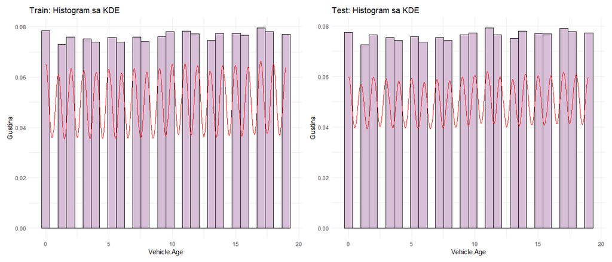

```r
plot.train <- ggplot(train, aes(x = Vehicle.Age)) +
  geom_histogram(aes(y = ..density..), bins = 30, fill = "thistle", color = "black") +
  geom_density(color = "red") +
  theme_minimal() +
  labs(title = "Train: Histogram sa KDE", x = "Vehicle.Age", y = "Gustina")

plot.test <- ggplot(test, aes(x = Vehicle.Age)) +
  geom_histogram(aes(y = ..density..), bins = 30, fill = "thistle", color = "black") +
  geom_density(color = "red") +
  theme_minimal() +
  labs(title = "Test: Histogram sa KDE", x = "Vehicle.Age", y = "Gustina")

plot.train | plot.test
```

Prikaz varijable Vehicle.Age pomocu boxplot-a:

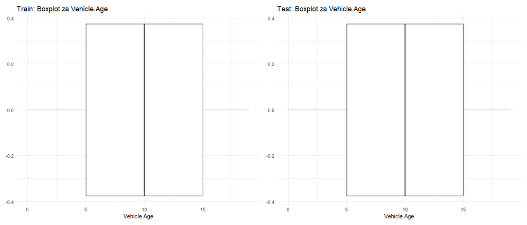

```r
plot.train <- ggplot(train, aes(x = Vehicle.Age))  +
  geom_boxplot() +
  theme_minimal() +
  labs(title = "Train: Boxplot za Vehicle.Age", x = "Vehicle.Age")

plot.test <- ggplot(test, aes(x = Vehicle.Age))  +
  geom_boxplot() +
  theme_minimal() +
  labs(title = "Test: Boxplot za Vehicle.Age", x = "Vehicle.Age")

plot.train | plot.test
```

Prikaz varijable Vehicle.Age pomocu Q-Q plota:

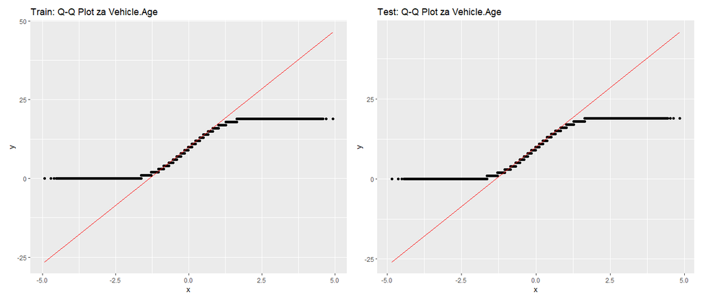

```r
plot.train <- ggplot(train, aes(sample = Vehicle.Age)) +
  stat_qq() +
  stat_qq_line(color = "red") +
  labs(title = "Train: Q-Q Plot za Vehicle.Age")

plot.test <- ggplot(test, aes(sample = Vehicle.Age)) +
  stat_qq() +
  stat_qq_line(color = "red") +
  labs(title = "Test: Q-Q Plot za Vehicle.Age")

plot.train | plot.test
```

Statisticko testiranje normalnosti varijable Vehicle.Age za train skup:

```r
set.seed(123)
p.values.train <- replicate(500, shapiro.test(sample(train$Vehicle.Age, 3000))$p.value)
p.mean.train <- mean(p.values.train)

if (p.mean.train > 0.05) {
  print("Train: Varijabla Vehicle.Age ima normalnu raspodelu.")
} else {
  print("Train: Varijabla Vehicle.Age nema normalnu raspodelu.")
}
```

```
[1] "Train: Varijabla Vehicle.Age nema normalnu raspodelu."
```

Statisticko testiranje normalnosti varijable Vehicle.Age za test skup:

```r
p.values.test <- replicate(500, shapiro.test(sample(test$Vehicle.Age, 3000))$p.value)
p.mean.test <- mean(p.values.test)

if (p.mean.test > 0.05) {
  print("Test: Varijabla Vehicle.Age ima normalnu raspodelu.")
} else {
  print("Test: Varijabla Vehicle.Age nema normalnu raspodelu.")
}
```

```
[1] "Test: Varijabla Vehicle.Age nema normalnu raspodelu."
```

## 7. Credit.Score

Osnovni opis varijable Credit.Score za train skup:

```r
summary(train$Credit.Score)
```

```
   Min. 1st Qu.  Median    Mean 3rd Qu.    Max.    NA's
  300.0   468.0   595.0   592.9   721.0   849.0  137882
```

Osnovni opis varijable Credit.Score za test skup:

```r
summary(test$Credit.Score)
```

```
   Min. 1st Qu.  Median    Mean 3rd Qu.    Max.    NA's
  300.0   468.0   595.0   592.9   721.0   849.0   91451
```

### Graficka reprezentacija podataka

Prikaz varijable Credit.Score pomocu histograma:

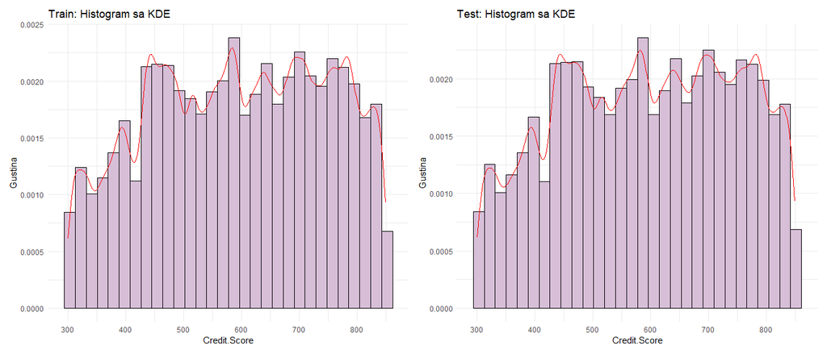

```r
plot.train <- ggplot(train, aes(x = Credit.Score)) +
  geom_histogram(aes(y = ..density..), bins = 30, fill = "thistle", color = "black") +
  geom_density(color = "red") +
  theme_minimal() +
  labs(title = "Train: Histogram sa KDE", x = "Credit.Score", y = "Gustina")

plot.test <- ggplot(test, aes(x = Credit.Score)) +
  geom_histogram(aes(y = ..density..), bins = 30, fill = "thistle", color = "black") +
  geom_density(color = "red") +
  theme_minimal() +
  labs(title = "Test: Histogram sa KDE", x = "Credit.Score", y = "Gustina")

plot.train | plot.test
```

Prikaz varijable Credit.Score pomocu boxplot-a:

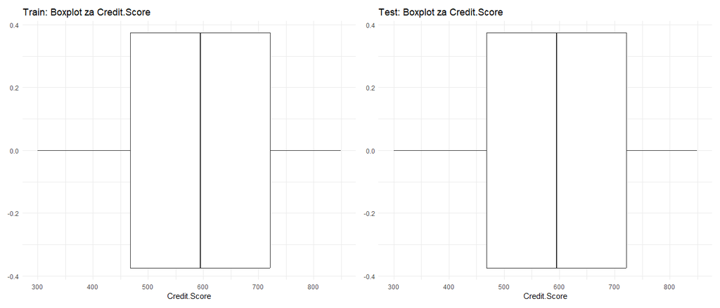

```r
plot.train <- ggplot(train, aes(x = Credit.Score))  +
  geom_boxplot() +
  theme_minimal() +
  labs(title = "Train: Boxplot za Credit.Score", x = "Credit.Score")

plot.test <- ggplot(test, aes(x = Credit.Score))  +
  geom_boxplot() +
  theme_minimal() +
  labs(title = "Test: Boxplot za Credit.Score", x = "Credit.Score")

plot.train | plot.test
```

Prikaz varijable Credit.Score pomocu Q-Q plota:

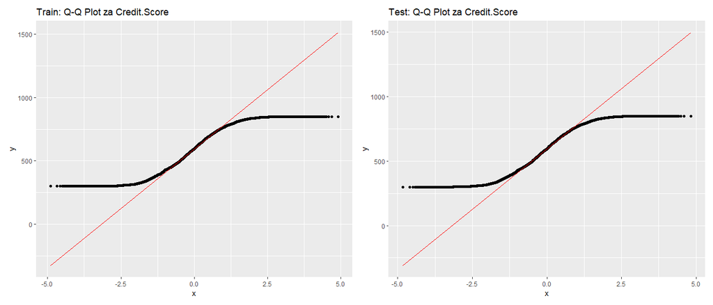

```r
plot.train <- ggplot(train, aes(sample = Credit.Score)) +
  stat_qq() +
  stat_qq_line(color = "red") +
  labs(title = "Train: Q-Q Plot za Credit.Score")

plot.test <- ggplot(test, aes(sample = Credit.Score)) +
  stat_qq() +
  stat_qq_line(color = "red") +
  labs(title = "Test: Q-Q Plot za Credit.Score")

plot.train | plot.test
```

Statisticko testiranje normalnosti varijable Credit.Score za train skup:

```r
set.seed(123)
p.values.train <- replicate(500, shapiro.test(sample(train$Credit.Score, 3000))$p.value)
p.mean.train <- mean(p.values.train)

if (p.mean.train > 0.05) {
  print("Train: Varijabla Credit.Score ima normalnu raspodelu.")
} else {
  print("Train: Varijabla Credit.Score nema normalnu raspodelu.")
}
```

```
[1] "Train: Varijabla Credit.Score nema normalnu raspodelu."
```

Statisticko testiranje normalnosti varijable Credit.Score za test skup:

```r
p.values.test <- replicate(500, shapiro.test(sample(test$Credit.Score, 3000))$p.value)
p.mean.test <- mean(p.values.test)

if (p.mean.test > 0.05) {
  print("Test: Varijabla Credit.Score ima normalnu raspodelu.")
} else {
  print("Test: Varijabla Credit.Score nema normalnu raspodelu.")
}
```

```
[1] "Test: Varijabla Credit.Score nema normalnu raspodelu."
```

## 8. Insurance.Duration

Osnovni opis varijable Insurance.Duration za train skup:

```r
summary(train$Insurance.Duration)
```

```
   Min. 1st Qu.  Median    Mean 3rd Qu.    Max.    NA's
  1.000   3.000   5.000   5.018   7.000   9.000       1
```

Osnovni opis varijable Insurance.Duration za test skup:

```r
summary(test$Insurance.Duration)
```

```
   Min. 1st Qu.  Median    Mean 3rd Qu.    Max.    NA's
  1.000   3.000   5.000   5.019   7.000   9.000       2
```

### Graficka reprezentacija podataka

Prikaz varijable Insurance.Duration pomocu histograma:

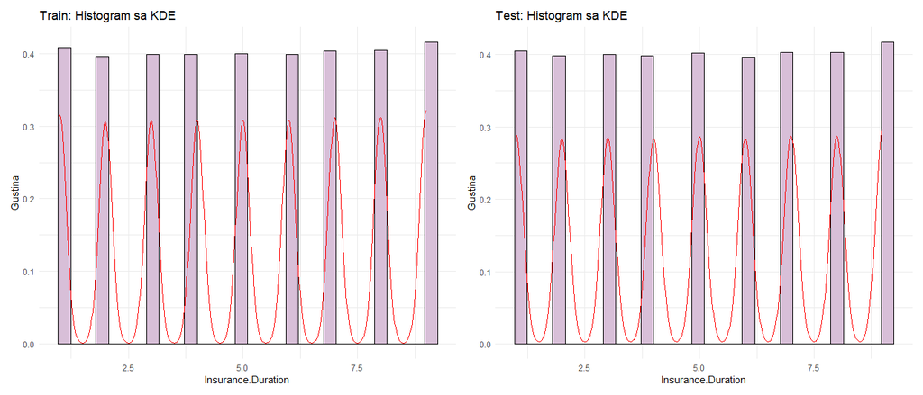

```r
plot.train <- ggplot(train, aes(x = Insurance.Duration)) +
  geom_histogram(aes(y = ..density..), bins = 30, fill = "thistle", color = "black") +
  geom_density(color = "red") +
  theme_minimal() +
  labs(title = "Train: Histogram sa KDE", x = "Insurance.Duration", y = "Gustina")

plot.test <- ggplot(test, aes(x = Insurance.Duration)) +
  geom_histogram(aes(y = ..density..), bins = 30, fill = "thistle", color = "black") +
  geom_density(color = "red") +
  theme_minimal() +
  labs(title = "Test: Histogram sa KDE", x = "Insurance.Duration", y = "Gustina")

plot.train | plot.test
```

Prikaz varijable Insurance.Duration pomocu boxplot-a:

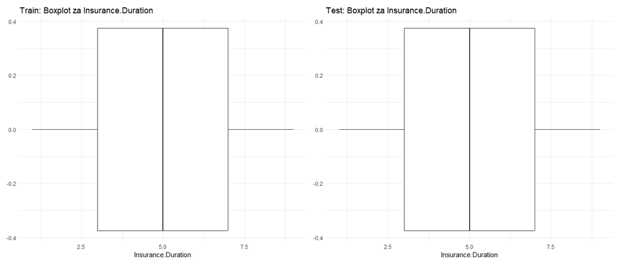

```r
plot.train <- ggplot(train, aes(x = Insurance.Duration))  +
  geom_boxplot() +
  theme_minimal() +
  labs(title = "Train: Boxplot za Insurance.Duration", x = "Insurance.Duration")

plot.test <- ggplot(test, aes(x = Insurance.Duration))  +
  geom_boxplot() +
  theme_minimal() +
  labs(title = "Test: Boxplot za Insurance.Duration", x = "Insurance.Duration")

plot.train | plot.test
```

Prikaz varijable Insurance.Duration pomocu Q-Q plota:

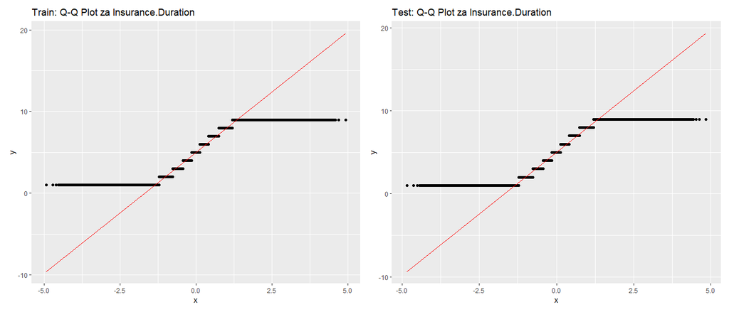

```r
plot.train <- ggplot(train, aes(sample = Insurance.Duration)) +
  stat_qq() +
  stat_qq_line(color = "red") +
  labs(title = "Train: Q-Q Plot za Insurance.Duration")

plot.test <- ggplot(test, aes(sample = Insurance.Duration)) +
  stat_qq() +
  stat_qq_line(color = "red") +
  labs(title = "Test: Q-Q Plot za Insurance.Duration")

plot.train | plot.test
```

Statisticko testiranje normalnosti varijable Insurance.Duration za train skup:

```r
set.seed(123)
p.values.train <- replicate(500, shapiro.test(sample(train$Insurance.Duration, 3000))$p.value)
p.mean.train <- mean(p.values.train)

if (p.mean.train > 0.05) {
  print("Train: Varijabla Insurance.Duration ima normalnu raspodelu.")
} else {
  print("Train: Varijabla Insurance.Duration nema normalnu raspodelu.")
}
```

```
[1] "Train: Varijabla Insurance.Duration nema normalnu raspodelu."
```

Statisticko testiranje normalnosti varijable Insurance.Duration za test skup:

```r
p.values.test <- replicate(500, shapiro.test(sample(test$Insurance.Duration, 3000))$p.value)
p.mean.test <- mean(p.values.test)

if (p.mean.test > 0.05) {
  print("Test: Varijabla Insurance.Duration ima normalnu raspodelu.")
} else {
  print("Test: Varijabla Insurance.Duration nema normalnu raspodelu.")
}
```

```
[1] "Test: Varijabla Insurance.Duration nema normalnu raspodelu."
```

## 9. Premium.Amount

Osnovi opis varijable Premium.Amount za train skup:

```r
summary(train$Premium.Amount)
```

```
   Min. 1st Qu.  Median    Mean 3rd Qu.    Max.
     20     514     872    1103    1509    4999
```

### Graficka reprezentacija podataka

Prikaz varijable Premium.Amount pomocu histograma za train skup:

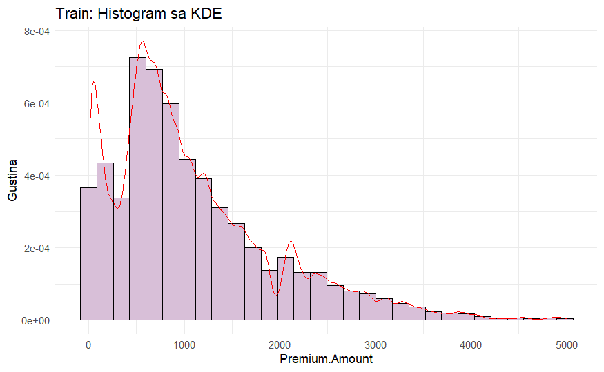

```r
ggplot(train, aes(x = Premium.Amount)) +
  geom_histogram(aes(y = ..density..), bins = 30, fill = "thistle", color = "black") +
  geom_density(color = "red") +
  theme_minimal() +
  labs(title = "Train: Histogram sa KDE", x = "Premium.Amount", y = "Gustina")
```

Prikaz varijable Premium.Amount pomocu boxplot-a za train skup:

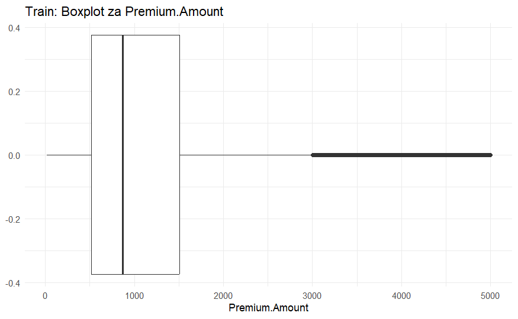

```r
ggplot(train, aes(x = Premium.Amount))  +
  geom_boxplot() +
  theme_minimal() +
  labs(title = "Train: Boxplot za Premium.Amount", x = "Premium.Amount")
```

Prikaz varijable Premium.Amount pomocu Q-Q plota za train skup:

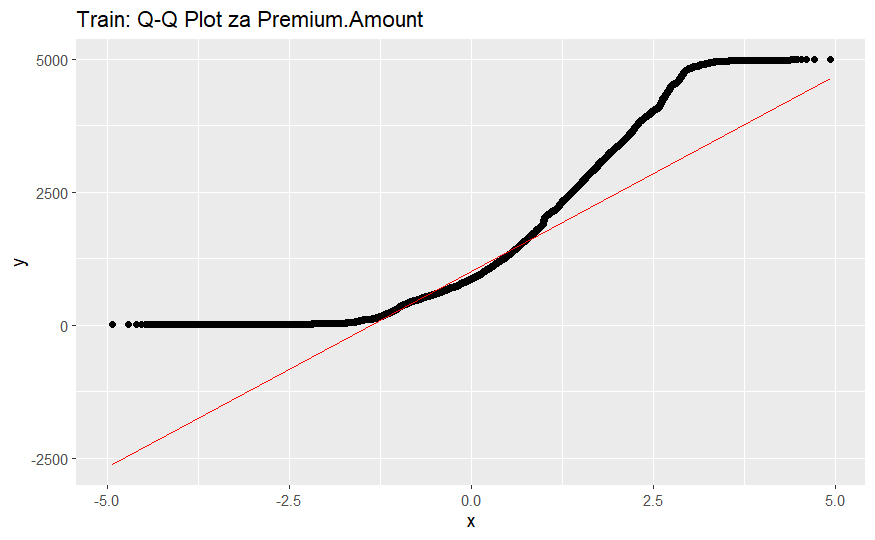

```r
ggplot(train, aes(sample = Premium.Amount)) +
  stat_qq() +
  stat_qq_line(color = "red") +
  labs(title = "Train: Q-Q Plot za Premium.Amount")
```

Statisticko testiranje normalnosti varijable Premium.Amount za train skup:

```r
set.seed(123)
p.values.train <- replicate(500, shapiro.test(sample(train$Premium.Amount, 3000))$p.value)
p.mean.train <- mean(p.values.train)

if (p.mean.train > 0.05) {
  print("Train: Varijabla Premium.Amount ima normalnu raspodelu.")
} else {
  print("Train: Varijabla Premium.Amount nema normalnu raspodelu.")
}
```

```
[1] "Train: Varijabla Premium.Amount nema normalnu raspodelu."
```

## Konvertovanje numerickih u kategorijske varijable

```r
num.cols <- c("Number.of.Dependents", "Previous.Claims", "Insurance.Duration")

train[num.cols] <- lapply(train[num.cols], as.factor)

dependents.levels <- c("0", "1", "2", "3", "4")

train$Number.of.Dependents <- ordered(
  train$Number.of.Dependents,
  levels = dependents.levels
)

claims.levels <- c("0", "1", "2", "3", "4", "5", "6", "7", "8", "9")

train$Previous.Claims <- ordered(
  train$Previous.Claims,
  levels = claims.levels
)

duration.levels <- c("1", "2", "3", "4", "5", "6", "7", "8", "9")

train$Insurance.Duration <- ordered(
  train$Insurance.Duration,
  levels = duration.levels
)

str(train[num.cols])
```

```
'data.frame':   1200000 obs. of  3 variables:
 $ Number.of.Dependents: Ord.factor w/ 5 levels "0"<"1"<"2"<"3"<..: 2 4 4 3 2 2 1 3 4 3 ...
 $ Previous.Claims     : Ord.factor w/ 10 levels "0"<"1"<"2"<"3"<..: 3 2 2 2 1 3 3 2 2 2 ...
 $ Insurance.Duration  : Ord.factor w/ 9 levels "1"<"2"<"3"<"4"<..: 5 2 3 1 4 5 6 5 8 3 ...
```

```r
test[num.cols] <- lapply(test[num.cols], as.factor)

test$Number.of.Dependents <- ordered(
  test$Number.of.Dependents,
  levels = dependents.levels
)

test$Previous.Claims <- ordered(
  test$Previous.Claims,
  levels = claims.levels
)

test$Insurance.Duration <- ordered(
  test$Insurance.Duration,
  levels = duration.levels
)

str(test[num.cols])
```

```
'data.frame':   800000 obs. of  3 variables:
 $ Number.of.Dependents: Ord.factor w/ 5 levels "0"<"1"<"2"<"3"<..: 5 3 1 4 3 3 4 4 5 3 ...
 $ Previous.Claims     : Ord.factor w/ 10 levels "0"<"1"<"2"<"3"<..: NA NA NA 2 NA NA 2 NA 1 2 ...
 $ Insurance.Duration  : Ord.factor w/ 9 levels "1"<"2"<"3"<"4"<..: 1 8 9 5 7 2 8 1 2 7 ...
```